# Reto 2

Blockchain Patrol

2023-11-17

# Crypto Datathon Reto 2

El objetivo de este reto es detectar un comportamiento anómalo en la fluctuación del precio de las criptomonedas en los exchanges. Para ello, es necesario elegir una serie de indicadores que muestren la actividad inusual de estos activos financieros estas plataformas, identificar patrones entre pares de monedas y establecer umbrales y señales de comportamientos inusuales en las plataformas de intercambio de criptomonedas, que funcionan como intermediarios para comprar, vender e intercambiar estos activos digitales.

```r
library(data.table)
library(tidyverse)
library(readr)
library(ggplot2)
library(PerformanceAnalytics)
library(dygraphs)
library(tidyr)
library(cluster)
library(NbClust)
library(fpc)
library(factoextra)
library(corrplot)
library(ggpubr)
library(purrr)
library(jsonlite)
```

Los order books que tenemos tienen horas con milisegundos, por lo que vamos a cambiar la opción para visualizar las fechas con este nivel de detalle.

```r
op <- options(digits.secs=3)
```

## 1. Calcula y define métricas que permitan configurar un sistema de alertas

Cargamos todos estos dataframes que previamente hemos salvado en ficheros .rda (se han subido también como parte de la entrega para poder ejecutar este rmd; se deben guardar en el mismo directorio en el que esté este fichero).

```r
load(file="crypto_orderbooks_agregados_ADA_USDT.Rda")
load(file="crypto_orderbooks_agregados_AVAX_USDT.Rda")
load(file="crypto_orderbooks_agregados_BTC_USDT.Rda")
load(file="crypto_orderbooks_agregados_DOT_USDT.Rda")
load(file="crypto_orderbooks_agregados_LTC_USDT.Rda")
load(file="crypto_orderbooks_agregados_MATIC_USDT.Rda")
load(file="crypto_orderbooks_agregados_SHIB_USDT.Rda")
load(file="crypto_orderbooks_agregados_SOL_USDT.Rda")
load(file="crypto_orderbooks_agregados_UNI_USDT.Rda")
load(file="crypto_orderbooks_agregados_XRP_USDT.Rda")
load(file="crypto_orderbooks_agregados_ETH_BTC.Rda")
load(file="crypto_orderbooks_agregados_DOGE_USDT.Rda")
```

Ahora vamos a poner NA en el primer registro de cada exchange de cada día en las variaciones, puesto que en ese caso no tiene sentido. Para ello creamos una función que ordena los datos por exchange.

```r
setNAsVariables <- function(datos){
    finBinance<-FALSE
    i<-1
    while (finBinance==FALSE && i<nrow(datos)){
      if(datos[i,]$Exchange=='binance'){
        finBinance<-TRUE
        datos[i,]$varPrecioMedioBids<-NA
        datos[i,]$varProfundidadBids<-NA
        datos[i,]$varPrecioMedioAsks<-NA
        datos[i,]$varProfundidadAsks<-NA
        datos[i,]$tiempoLlegada<-NA
      }
      i<-i+1
    }
    finKucoin<-FALSE
    i<-1
    while (finKucoin==FALSE & i<nrow(datos)){
      if(datos[i,]$Exchange=='kucoin'){
        finKucoin<-TRUE
        datos[i,]$varPrecioMedioBids<-NA
        datos[i,]$varProfundidadBids<-NA
        datos[i,]$varPrecioMedioAsks<-NA
        datos[i,]$varProfundidadAsks<-NA
        datos[i,]$tiempoLlegada<-NA
      }
    i<-i+1
    }
    finokx<-FALSE
    i<-1
    while (finokx==FALSE & i<nrow(datos)){
      if(datos[i,]$Exchange=='okx'){
        finokx<-TRUE
        datos[i,]$varPrecioMedioBids<-NA
        datos[i,]$varProfundidadBids<-NA
        datos[i,]$varPrecioMedioAsks<-NA
        datos[i,]$varProfundidadAsks<-NA
        datos[i,]$tiempoLlegada<-NA
      }
    i<-i+1
    }
    return(datos)
}
```

Ahora utilizamos la función anterior para limpiar los lags erróneos.

```r
datos_ADA_USDT <- datos_ADA_USDT[order(datos_ADA_USDT$Hora),]
datos_ADA_USDT<-setNAsVariables(datos_ADA_USDT)

datos_AVAX_USDT <- datos_AVAX_USDT[order(datos_AVAX_USDT$Hora),]
datos_AVAX_USDT<-setNAsVariables(datos_AVAX_USDT)

datos_BTC_USDT <- datos_BTC_USDT[order(datos_BTC_USDT$Hora),]
datos_BTC_USDT<-setNAsVariables(datos_BTC_USDT)

datos_DOGE_USDT <- datos_DOGE_USDT[order(datos_DOGE_USDT$Hora),]
datos_DOGE_USDT<-setNAsVariables(datos_DOGE_USDT)

datos_DOT_USDT <- datos_DOGE_USDT[order(datos_DOT_USDT$Hora),]
datos_DOT_USDT<-setNAsVariables(datos_DOT_USDT)

datos_ETH_BTC <- datos_ETH_BTC[order(datos_ETH_BTC$Hora),]
datos_ETH_BTC<-setNAsVariables(datos_ETH_BTC)

datos_LTC_USDT <- datos_LTC_USDT[order(datos_LTC_USDT$Hora),]
datos_LTC_USDT<-setNAsVariables(datos_LTC_USDT)

datos_MATIC_USDT <- datos_MATIC_USDT[order(datos_MATIC_USDT$Hora),]
datos_MATIC_USDT<-setNAsVariables(datos_MATIC_USDT)

datos_SHIB_USDT <- datos_SHIB_USDT[order(datos_SHIB_USDT$Hora),]
datos_SHIB_USDT<-setNAsVariables(datos_SHIB_USDT)

datos_SOL_USDT <- datos_SOL_USDT[order(datos_SOL_USDT$Hora),]
datos_SOL_USDT<-setNAsVariables(datos_SOL_USDT)

datos_UNI_USDT <- datos_UNI_USDT[order(datos_UNI_USDT$Hora),]
datos_UNI_USDT<-setNAsVariables(datos_UNI_USDT)

datos_XRP_USDT <- datos_XRP_USDT[order(datos_XRP_USDT$Hora),]
datos_XRP_USDT<-setNAsVariables(datos_XRP_USDT)
```

Ya tenemos nuestros dataframes listos para hacer el análisis de datos y con las métricas que ya hemos definido:

- Valor medio de la demanda recogida en la entrada
- Cantidad de demanda recogida en la entrada
- Valor medio de la oferta recogida en la entrada
- Cantidad de oferta recogida en la entrada
- Variación del valor de la demanda con respecto a la entrada anterior en el mismo exchange
- Variación del valor de la oferta con respecto a la entrada anterior en el mismo exchange
- Variación de la cantidad de demanda con respecto a la entrada anterior en el mismo exchange
- Variación de la cantidad de oferta con respecto a la entrada anterior en el mismo exchange
- Tiempo que transcurre con respecto a la entrada anterior en el mismo exchange
- Sentimiento de compra-venta calculado como la ratio entre demanda y oferta

## 2. Encuentra patrones

Vamos a calcular la correlación que hay entre las distintas métricas que hemos calculado para distintas monedas.

Creamos en primer lugar una función a la que vamos a llamar para las distintas monedas.

Estudiaremos las relaciones entre las diferentes Cryptos y USDT (stablecoin) y entre ETH/BTC que son las monedas que intervienen en la casi totalidad de los intercambios.

```r
VisualizarCorrelacion <- function(datos){
  corrplot(cor(datos[, 4:7], use = "pairwise.complete.obs"), method = "number", addCoef.col = 1, tl.cex = 0.7)
}
```

Visualizamos en primer lugar las correlaciones para ADA/USDT.

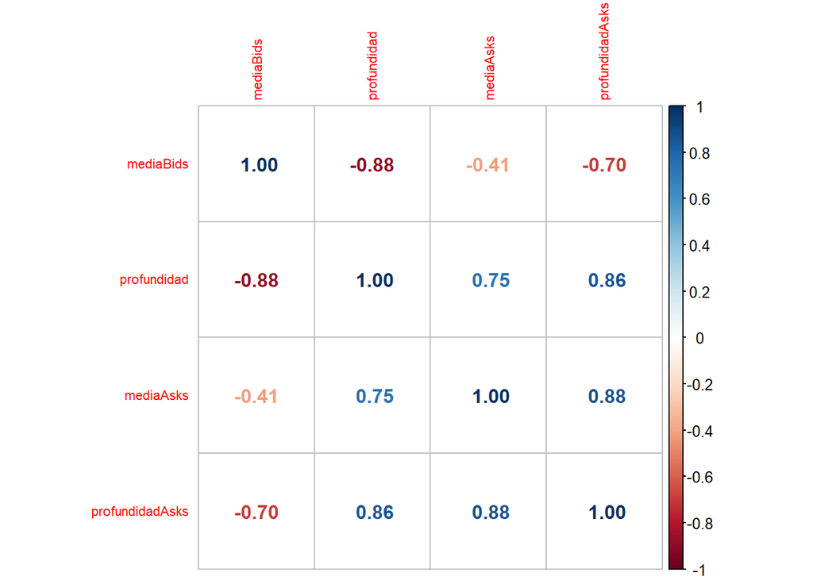

```r
VisualizarCorrelacion (datos_ADA_USDT)
```

Vamos a comparar con las correlaciones de BTC/USDT.

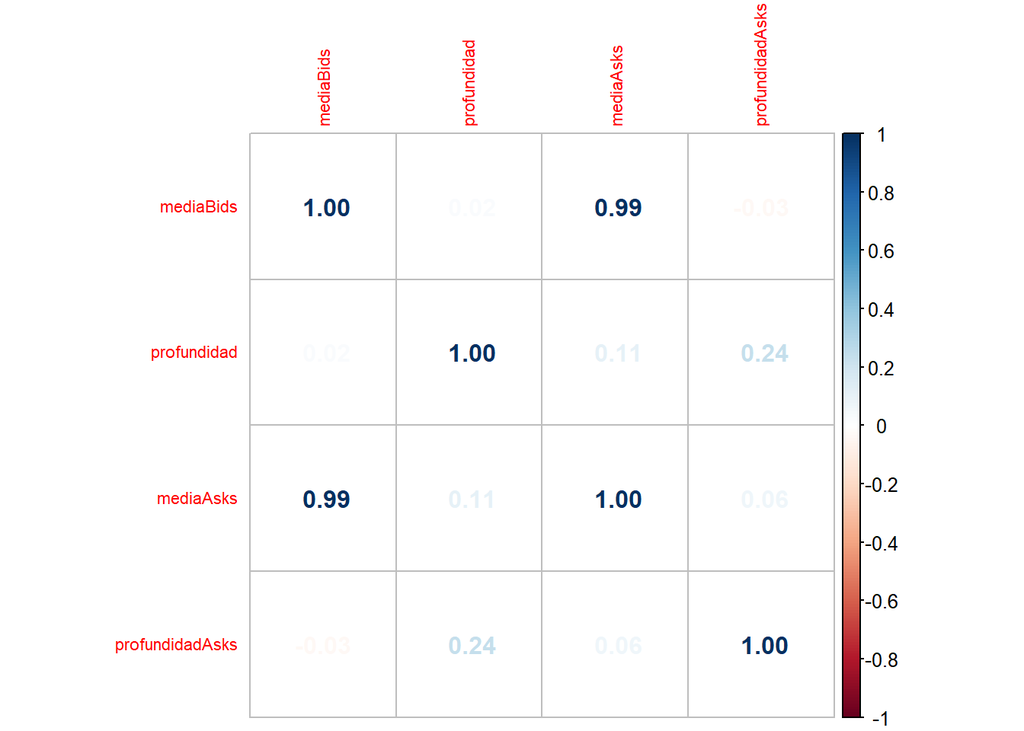

```r
VisualizarCorrelacion (datos_BTC_USDT)
```

Y, finalmente, con las de ETH/BTC.

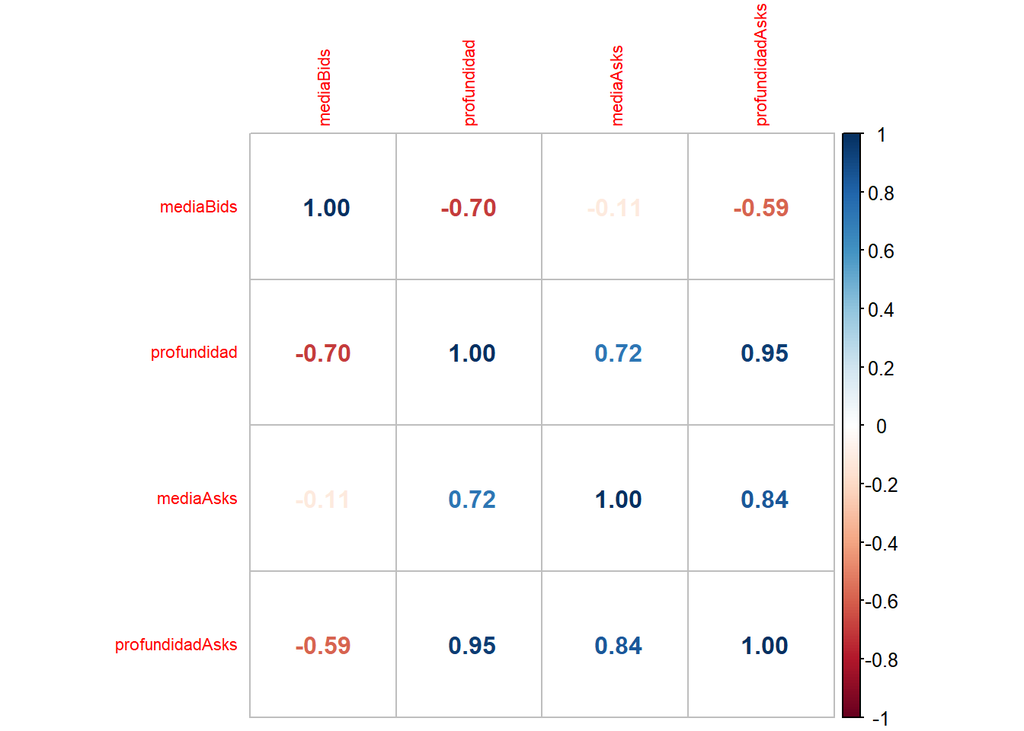

```r
VisualizarCorrelacion (datos_ETH_BTC)
```

Las correlaciones para ADA/USDT y para ETH/BTC son muy parecidas. Vemos que las correlaciones más fuertes parecen ser las siguientes:

- Precio medio de bids - Profundidad de bids. Existe fuerte correlación negativa. Cuanto más demanda hay, menor es el precio de ésta.
- Profundidad de bids - Profundidad de asks. Existe fuerte correlación positiva. Cuantas más oferta hay también hay mayor demanda.
- Precio medio de asks - Profundidad de asks. Existe fuerte correlación positiva. Cuanto mayor es el precio de la oferta, más operaciones de oferta hay.

Podemos ver las correlaciones mencionadas para ADA/USDT a través de gráficos de dispersión.

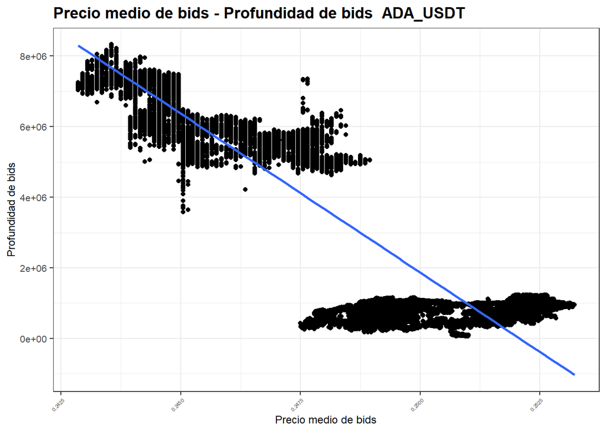

```r
VisualizarCorrelacionMediaBids_Profundidad <- function(datos, moneda){
ggplot(datos, aes(x = mediaBids, y = profundidad)) +
  geom_point() +
  geom_smooth(method=lm) +
  ggtitle(paste ("Precio medio de bids - Profundidad de bids " , moneda)) +
  theme_bw() +
  theme(axis.text = element_text(size = 8), axis.title =  element_text(size = 9), plot.title = element_text(face = 'bold'), axis.text.x = element_text(angle = 45, vjust = 1, hjust=1, size=4), strip.background=element_rect(colour="black", fill="#f4f4f4")) +
  labs(x = "Precio medio de bids", y = "Profundidad de bids")
}

#Poner el dataset que queramos
VisualizarCorrelacionMediaBids_Profundidad (datos_ADA_USDT, "ADA_USDT")
```

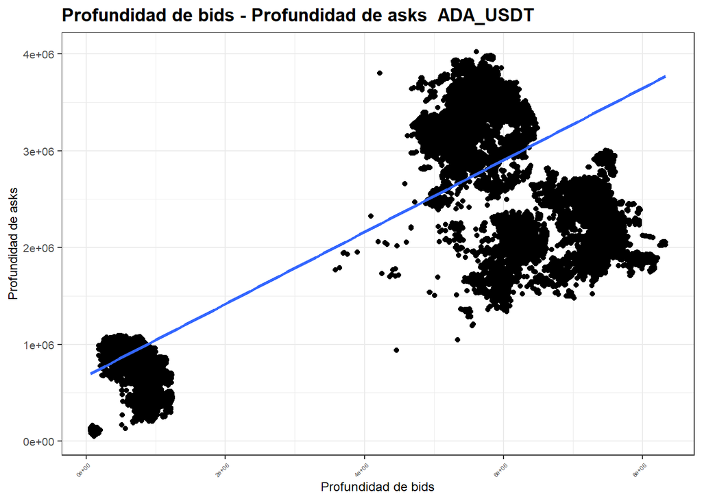

```r
VisualizarCorrelacionProfBids_ProfAsks <- function(datos, moneda){
ggplot(datos, aes(x = profundidad, y = profundidadAsks)) +
  geom_point() +
  geom_smooth(method=lm) +
  ggtitle(paste ("Profundidad de bids - Profundidad de asks ", moneda)) +
  theme_bw() +
  theme(axis.text = element_text(size = 8), axis.title =  element_text(size = 9), plot.title = element_text(face = 'bold'), axis.text.x = element_text(angle = 45, vjust = 1, hjust=1, size=4), strip.background=element_rect(colour="black", fill="#f4f4f4")) +
  labs(x = "Profundidad de bids", y = "Profundidad de asks")
}

#Poner el dataset que queramos
VisualizarCorrelacionProfBids_ProfAsks (datos_ADA_USDT, "ADA_USDT")
```

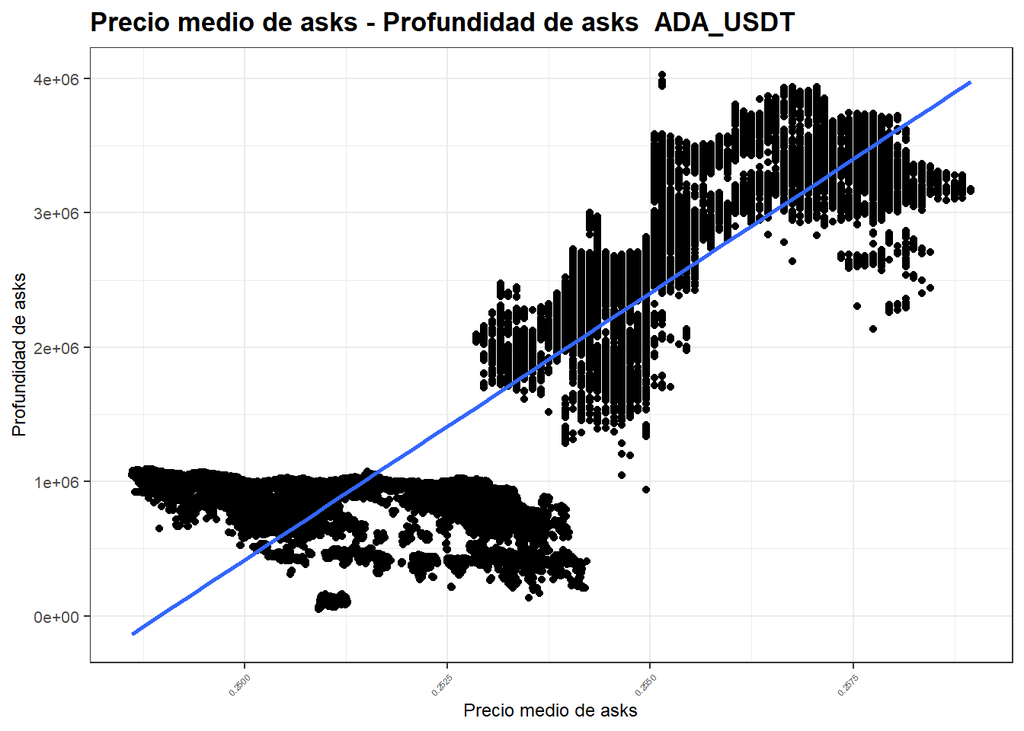

```r
VisualizarCorrelacionMediaAsks_ProfAsks <- function(datos, moneda){
ggplot(datos, aes(x = mediaAsks, y = profundidadAsks)) +
  geom_point() +
  geom_smooth(method=lm) +
  ggtitle(paste("Precio medio de asks - Profundidad de asks ", moneda)) +
  theme_bw() +
  theme(axis.text = element_text(size = 8), axis.title =  element_text(size = 9), plot.title = element_text(face = 'bold'), axis.text.x = element_text(angle = 45, vjust = 1, hjust=1, size=4), strip.background=element_rect(colour="#black", fill="#f4f4f4")) +
  labs(x = "Precio medio de asks", y = "Profundidad de asks")
}

#Poner el dataset que queramos
VisualizarCorrelacionMediaAsks_ProfAsks(datos_ADA_USDT, "ADA_USDT")
```

## 3. Elige umbrales de comportamiento anómalo

Para ver umbrales de comportamiento anómalo, podemos calcular los cuantiles para las métricas calculadas para la demanda (los bids) Por ejemplo, para el cambio BTC/USDT:

```r
CalculaCuantilesBids <- function(datos){
print ("Media Bids")
print(quantile(datos$mediaBids, c(.25, .50, .75)))
print ("Profundidad Bids")
print(quantile(datos$profundidad, c(.25, .50, .75)))
print ("Variación Precio Medio Bids")
print(quantile(datos$varPrecioMedioBids, c(.25, .50, .75), na.rm = T))
print ("Variación Profundidad Bids")
print(quantile(datos$varProfundidadBids, c(.25, .50, .75), na.rm = T))
}

#Dataset BT_USDT
CalculaCuantilesBids(datos_BTC_USDT)
```

```
## [1] "Media Bids"
##      25%      50%      75%
## 27438.65 27571.42 27645.26
## [1] "Profundidad Bids"
##      25%      50%      75%
## 14.16272 22.96303 29.42438
## [1] "Variación Precio Medio Bids"
##           25%           50%           75%
## -6.396982e-05  0.000000e+00  2.132541e-04
## [1] "Variación Profundidad Bids"
##       25%       50%       75%
##  93567.94 119870.45 194233.38
```

Y para la oferta (asks).

```r
CalculaCuantilesAsks <- function(datos){
print ("Media Asks")
print(quantile(datos$mediaAsks, c(.25, .50, .75)))
print ("Profundidad Asks")
print(quantile(datos$profundidadAsks, c(.25, .50, .75)))
print ("Variación Precio Medio Asks")
print(quantile(datos$varPrecioMedioAsks, c(.25, .50, .75), na.rm = T))
print ("Variación Profundidad Asks")
print(quantile(datos$varProfundidadAsks, c(.25, .50, .75), na.rm = T))
}

#Dataset BT_USDT
CalculaCuantilesAsks(datos_BTC_USDT)
```

```
## [1] "Media Asks"
##      25%      50%      75%
## 27457.35 27589.30 27662.75
## [1] "Profundidad Asks"
##      25%      50%      75%
## 13.91972 23.73057 31.34131
## [1] "Variación Precio Medio Asks"
##         25%         50%         75%
## -0.11706544 -0.02802595 -0.01424582
## [1] "Variación Profundidad Asks"
##       25%       50%       75%
##  87926.16 116023.28 197758.47
```

Los valores que se encuentren fuera de esos cuantiles, podrían cosiderarse sospechosos.

Dibujamos los gráficos de cajas para tener una representación visual de los valores medios de precios y profundidad, para demanda (bids) y oferta (asks)

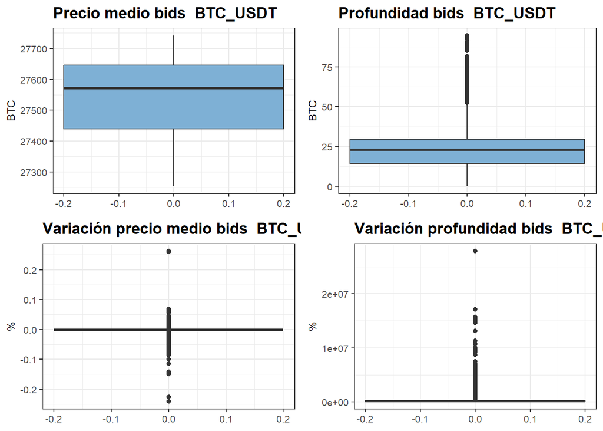

```r
PintarGraficoCajasBids <- function(datos, moneda){
p1 <- ggplot(datos, aes(y = mediaBids)) +
  geom_boxplot(width = 0.4, fill = "#7eb0d5") +
  ggtitle(paste ("Precio medio bids ", moneda)) +
  theme_bw() +
  theme(axis.text = element_text(size = 8), axis.title =  element_text(size = 9), plot.title = element_text(face = 'bold')) +
  labs(y = bquote(BTC))

p2 <- ggplot(datos, aes(y = profundidad)) +
  geom_boxplot(width = 0.4, fill = "#7eb0d5") +
  ggtitle(paste("Profundidad bids ", moneda)) +
  theme_bw() +
  theme(axis.text = element_text(size = 8), axis.title =  element_text(size = 9), plot.title = element_text(face = 'bold')) +
  labs(y = bquote(BTC))

p3 <- ggplot(datos, aes(y = varPrecioMedioBids)) +
  geom_boxplot(width = 0.4, fill = "#7eb0d5") +
  ggtitle(paste("Variación precio medio bids ", moneda)) +
  theme_bw() +
  theme(axis.text = element_text(size = 8), axis.title =  element_text(size = 9), plot.title = element_text(face = 'bold')) +
  labs(y = "%")

p4 <- ggplot(datos, aes(y = varProfundidadBids)) +
  geom_boxplot(width = 0.4, fill = "#7eb0d5") +
  ggtitle(paste("Variación profundidad bids ", moneda)) +
  theme_bw() +
  theme(axis.text = element_text(size = 8), axis.title =  element_text(size = 9), plot.title = element_text(face = 'bold')) +
  labs(y = "%")

ggarrange(ggarrange(p1, p2),
          ggarrange(p3, p4),
          nrow = 2
          )
}

#Dataset BTC_USDT
PintarGraficoCajasBids(datos_BTC_USDT, "BTC_USDT")
```

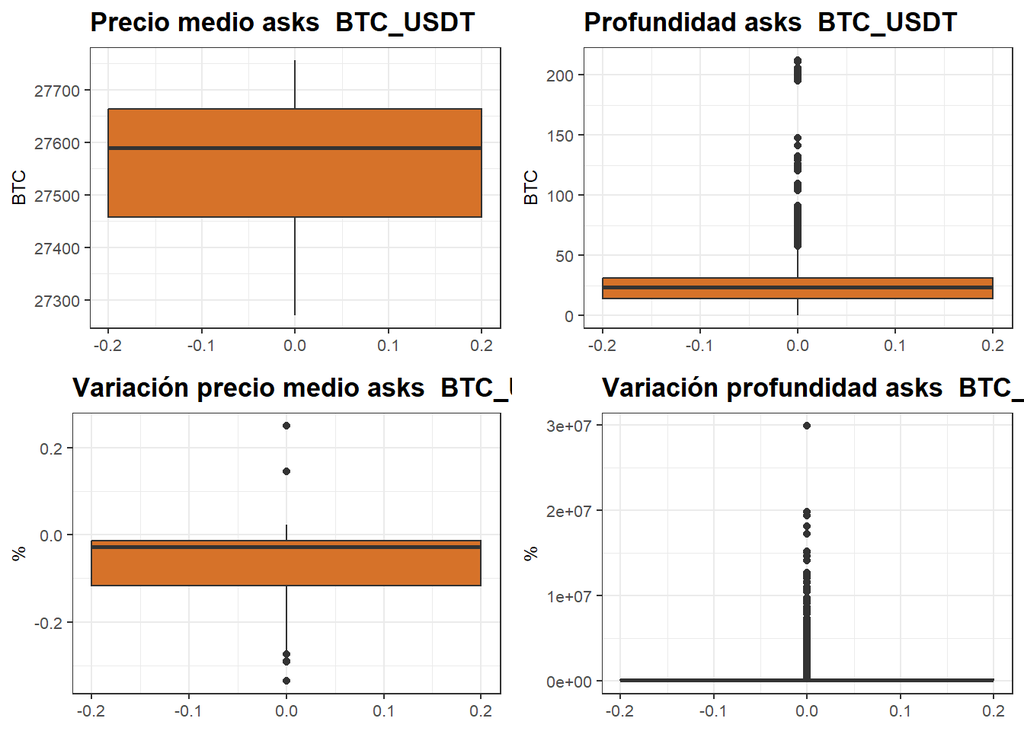

```r
PintarGraficoCajasAsks <- function(datos, moneda){
p1 <- ggplot(datos, aes(y = mediaAsks)) +
  geom_boxplot(width = 0.4, fill = "#d67229") +
  ggtitle(paste("Precio medio asks ", moneda)) +
  theme_bw() +
  theme(axis.text = element_text(size = 8), axis.title =  element_text(size = 9), plot.title = element_text(face = 'bold')) +
  labs(y = bquote(BTC))

p2 <- ggplot(datos, aes(y = profundidadAsks)) +
  geom_boxplot(width = 0.4, fill = "#d67229") +
  ggtitle(paste("Profundidad asks ", moneda)) +
  theme_bw() +
  theme(axis.text = element_text(size = 8), axis.title =  element_text(size = 9), plot.title = element_text(face = 'bold')) +
  labs(y = bquote(BTC))

p3 <- ggplot(datos, aes(y = varPrecioMedioAsks)) +
  geom_boxplot(width = 0.4, fill = "#d67229") +
  ggtitle(paste("Variación precio medio asks ", moneda)) +
  theme_bw() +
  theme(axis.text = element_text(size = 8), axis.title =  element_text(size = 9), plot.title = element_text(face = 'bold')) +
  labs(y = "%")

p4 <- ggplot(datos, aes(y = varProfundidadAsks)) +
  geom_boxplot(width = 0.4, fill = "#d67229") +
  ggtitle(paste ("Variación profundidad asks ", moneda)) +
  theme_bw() +
  theme(axis.text = element_text(size = 8), axis.title =  element_text(size = 9), plot.title = element_text(face = 'bold')) +
  labs(y = "%")

ggarrange(ggarrange(p1, p2),
          ggarrange(p3, p4),
          nrow = 2
          )
}

PintarGraficoCajasAsks(datos_BTC_USDT, "BTC_USDT")
```

## 4. Visualización de los datos

### 4.1 Evolución de precio medio de oferta y demanda

Como tenemos las variaciones de precios en el tiempo, vamos a estudiar su comportamiento.

Se puede apreciar que hay varios gaps de tiempo sin datos, uno especialmente grande de varias horas entre las 00:32 y las 07:11.

```r
grafica_evolucion_media_bids_asks <- function (datos, time_lag, titulo_grafico, y_label) {
  datos_agrupados <- datos %>%
    mutate(Hora_agrupada = cut(Hora, breaks = time_lag)) %>%
    group_by(Hora_agrupada) %>%
    summarize(mediaBidsAgrupada = mean(mediaBids), mediaAsksAgrupada = mean(mediaAsks)) %>%
    mutate(Hora_agrupada = as.POSIXct(Hora_agrupada))

  ggplot(datos_agrupados, aes()) +
    geom_line(aes(x = Hora_agrupada, y = mediaBidsAgrupada, color = "Bids"), size = 0.5) +
    geom_line(aes(x = Hora_agrupada, y = mediaAsksAgrupada, color = "Asks"), size = 0.5) +
    ggtitle(titulo_grafico) +
    theme_bw() +
    theme(axis.text = element_text(size = 8), axis.title =  element_text(size = 9), plot.title = element_text(face = 'bold')) +
    labs(x = element_blank(), y = y_label) +
    scale_color_manual(name="Series",
                     values=c("#0047AB", "#5F9EA0"))
}
```

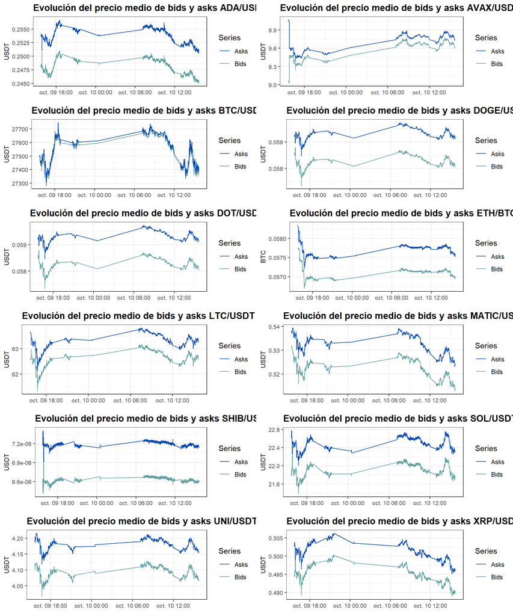

```r
p1 <- grafica_evolucion_media_bids_asks(datos_ADA_USDT, "10 sec", "Evolución del precio medio de bids y asks ADA/USDT", "USDT")
p2 <- grafica_evolucion_media_bids_asks(datos_AVAX_USDT, "10 sec", "Evolución del precio medio de bids y asks AVAX/USDT", "USDT")
p3 <- grafica_evolucion_media_bids_asks(datos_BTC_USDT, "10 sec", "Evolución del precio medio de bids y asks BTC/USDT", "USDT")
p4 <- grafica_evolucion_media_bids_asks(datos_DOGE_USDT, "10 sec", "Evolución del precio medio de bids y asks DOGE/USDT", "USDT")
p5 <- grafica_evolucion_media_bids_asks(datos_DOT_USDT, "10 sec", "Evolución del precio medio de bids y asks DOT/USDT", "USDT")
p6 <- grafica_evolucion_media_bids_asks(datos_ETH_BTC, "10 sec", "Evolución del precio medio de bids y asks ETH/BTC", "BTC")
p7 <- grafica_evolucion_media_bids_asks(datos_LTC_USDT, "10 sec", "Evolución del precio medio de bids y asks LTC/USDT", "USDT")
p8 <- grafica_evolucion_media_bids_asks(datos_MATIC_USDT, "10 sec", "Evolución del precio medio de bids y asks MATIC/USDT", "USDT")
p9 <- grafica_evolucion_media_bids_asks(datos_SHIB_USDT, "10 sec", "Evolución del precio medio de bids y asks SHIB/USDT", "USDT")
p10 <- grafica_evolucion_media_bids_asks(datos_SOL_USDT, "10 sec", "Evolución del precio medio de bids y asks SOL/USDT", "USDT")
p11 <- grafica_evolucion_media_bids_asks(datos_UNI_USDT, "10 sec", "Evolución del precio medio de bids y asks UNI/USDT", "USDT")
p12 <- grafica_evolucion_media_bids_asks(datos_XRP_USDT, "10 sec", "Evolución del precio medio de bids y asks XRP/USDT", "USDT")

ggarrange(ggarrange(p1, p2),
          ggarrange(p3, p4),
          ggarrange(p5, p6),
          ggarrange(p7, p8),
          ggarrange(p9, p10),
          ggarrange(p11, p12),
          nrow = 6
          )
```

### 4.2 Evolución de profundidad de oferta y demanda

Vamos a estudiar también la profundidad:

```r
grafica_evolucion_profundidad_bids_asks <- function (datos, time_lag, titulo_grafico, y_label) {
  datos_agrupados <- datos %>%
    mutate(Hora_agrupada = cut(Hora, breaks = time_lag)) %>%
    group_by(Hora_agrupada) %>%
    summarize(profBidsAgrupada = mean(profundidad), profAsksAgrupada = mean(profundidadAsks)) %>%
    mutate(Hora_agrupada = as.POSIXct(Hora_agrupada))

  ggplot(datos_agrupados, aes()) +
    geom_line(aes(x = Hora_agrupada, y = profBidsAgrupada, color = "Bids"), size = 0.5) +
    geom_line(aes(x = Hora_agrupada, y = profAsksAgrupada, color = "Asks"), size = 0.5) +
    ggtitle(titulo_grafico) +
    theme_bw() +
    theme(axis.text = element_text(size = 8), axis.title =  element_text(size = 9), plot.title = element_text(face = 'bold')) +
    labs(x = element_blank(), y = y_label) +
    scale_color_manual(name="Series",
                     values=c("#0047AB", "#5F9EA0"))
}
```

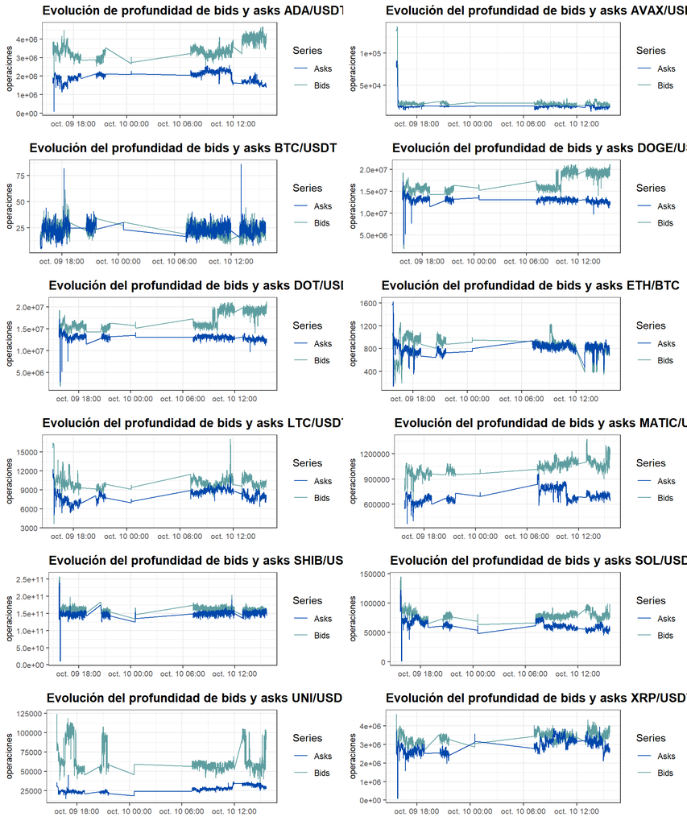

```r
p1 <- grafica_evolucion_profundidad_bids_asks(datos_ADA_USDT, "10 sec", "Evolución de profundidad de bids y asks ADA/USDT", "operaciones")
p2 <- grafica_evolucion_profundidad_bids_asks(datos_AVAX_USDT, "10 sec", "Evolución del profundidad de bids y asks AVAX/USDT", "operaciones")
p3 <- grafica_evolucion_profundidad_bids_asks(datos_BTC_USDT, "10 sec", "Evolución del profundidad de bids y asks BTC/USDT", "operaciones")
p4 <- grafica_evolucion_profundidad_bids_asks(datos_DOGE_USDT, "10 sec", "Evolución del profundidad de bids y asks DOGE/USDT", "operaciones")
p5 <- grafica_evolucion_profundidad_bids_asks(datos_DOT_USDT, "10 sec", "Evolución del profundidad de bids y asks DOT/USDT", "operaciones")
p6 <- grafica_evolucion_profundidad_bids_asks(datos_ETH_BTC, "10 sec", "Evolución del profundidad de bids y asks ETH/BTC", "operaciones")
p7 <- grafica_evolucion_profundidad_bids_asks(datos_LTC_USDT, "10 sec", "Evolución del profundidad de bids y asks LTC/USDT", "operaciones")
p8 <- grafica_evolucion_profundidad_bids_asks(datos_MATIC_USDT, "10 sec", "Evolución del profundidad de bids y asks MATIC/USDT", "operaciones")
p9 <- grafica_evolucion_profundidad_bids_asks(datos_SHIB_USDT, "10 sec", "Evolución del profundidad de bids y asks SHIB/USDT", "operaciones")
p10 <- grafica_evolucion_profundidad_bids_asks(datos_SOL_USDT, "10 sec", "Evolución del profundidad de bids y asks SOL/USDT", "operaciones")
p11 <- grafica_evolucion_profundidad_bids_asks(datos_UNI_USDT, "10 sec", "Evolución del profundidad de bids y asks UNI/USDT", "operaciones")
p12 <- grafica_evolucion_profundidad_bids_asks(datos_XRP_USDT, "10 sec", "Evolución del profundidad de bids y asks XRP/USDT", "operaciones")

ggarrange(ggarrange(p1, p2),
          ggarrange(p3, p4),
          ggarrange(p5, p6),
          ggarrange(p7, p8),
          ggarrange(p9, p10),
          ggarrange(p11, p12),
          nrow = 6
          )
```

En la mayoría de los casos vemos que hay una fuerte caída repentina de la oferta durante el día 9 alrededor de las 16:00. Si miramos las gráficas de los precios medios, vemos que esto se tradujo, un poco después, en una caída en el precio medio tanto de oferta como de demanda.

### 4.3 Precio medio de demanda con señales de alerta

En las siguientes gráficas vamos a mostrar los valores de precio medio de demanda (bids), mostrando líneas que sirvan para visualizar los posibles valores de alertas. Hemos seleccionado como valores sospechosos aquellos que pasan del percentil 95 o aquellos por debajo del percentil 5. Estos valores son configurables en la función grafica_evolucion_media_bids (se pasan como parámetro).

```r
grafica_evolucion_media_bids <- function (datos, time_lag, titulo_grafico, y_label, i, limits) {
  datos_agrupados <- datos %>%
    mutate(Hora_agrupada = cut(Hora, breaks = time_lag)) %>%
    group_by(Hora_agrupada) %>%
    summarize(mediaBidsAgrupada = mean(mediaBids)) %>%
    mutate(Hora_agrupada = as.POSIXct(Hora_agrupada))

  ggplot(datos_agrupados, aes(x = Hora_agrupada, y = mediaBidsAgrupada, group = 1)) +
    geom_line(size = 0.5, color = "#0047AB") +
    ggtitle(titulo_grafico) +
    theme_bw() +
    theme(axis.text = element_text(size = 8), axis.title =  element_text(size = 9), plot.title = element_text(face = 'bold')) +
    labs(x = element_blank(), y = y_label) +
    geom_hline(yintercept = quantile(datos_agrupados$mediaBidsAgrupada, limits), color = "red")
}
```

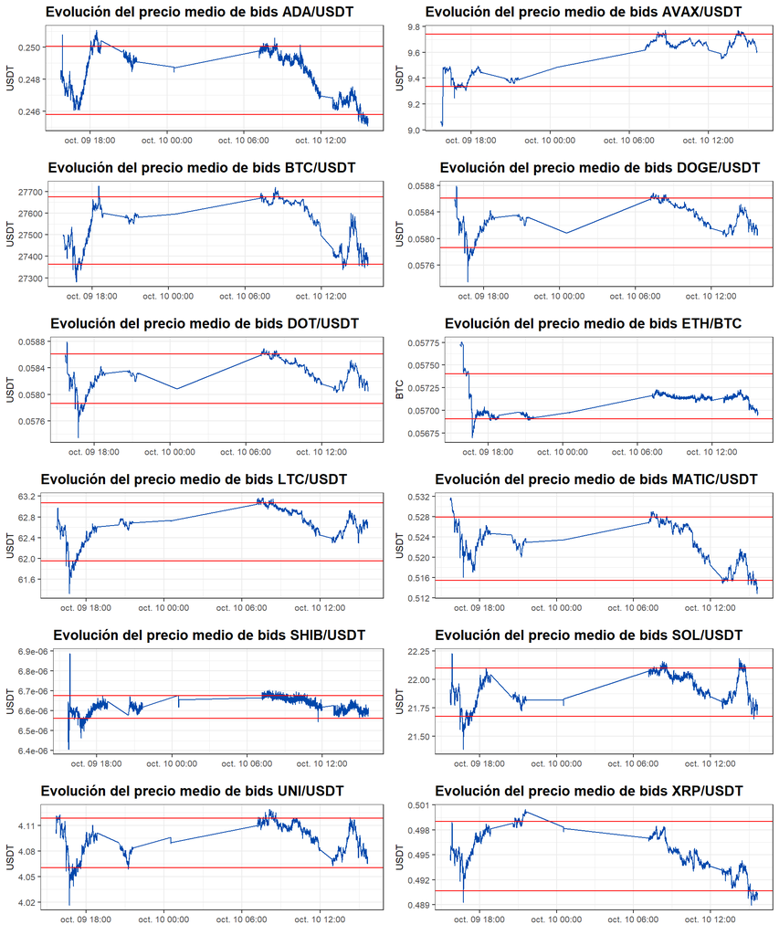

```r
p1 <- grafica_evolucion_media_bids(datos_ADA_USDT, "10 sec", "Evolución del precio medio de bids ADA/USDT", "USDT", 1, c(.05, .95))
p2 <- grafica_evolucion_media_bids(datos_AVAX_USDT, "10 sec", "Evolución del precio medio de bids AVAX/USDT", "USDT", 2, c(.05, .95))
p3 <- grafica_evolucion_media_bids(datos_BTC_USDT, "10 sec", "Evolución del precio medio de bids BTC/USDT", "USDT", 12, c(.05, .95))
p4 <- grafica_evolucion_media_bids(datos_DOGE_USDT, "10 sec", "Evolución del precio medio de bids DOGE/USDT", "USDT", 3, c(.05, .95))
p5 <- grafica_evolucion_media_bids(datos_DOT_USDT, "10 sec", "Evolución del precio medio de bids DOT/USDT", "USDT", 4, c(.05, .95))
p6 <- grafica_evolucion_media_bids(datos_ETH_BTC, "10 sec", "Evolución del precio medio de bids ETH/BTC", "BTC", 5, c(.05, .95))
p7 <- grafica_evolucion_media_bids(datos_LTC_USDT, "10 sec", "Evolución del precio medio de bids LTC/USDT", "USDT", 6, c(.05, .95))
p8 <- grafica_evolucion_media_bids(datos_MATIC_USDT, "10 sec", "Evolución del precio medio de bids MATIC/USDT", "USDT", 7, c(.05, .95))
p9 <- grafica_evolucion_media_bids(datos_SHIB_USDT, "10 sec", "Evolución del precio medio de bids SHIB/USDT", "USDT", 8, c(.05, .95))
p10 <- grafica_evolucion_media_bids(datos_SOL_USDT, "10 sec", "Evolución del precio medio de bids SOL/USDT", "USDT", 9, c(.05, .95))
p11 <- grafica_evolucion_media_bids(datos_UNI_USDT, "10 sec", "Evolución del precio medio de bids UNI/USDT", "USDT", 10, c(.05, .95))
p12 <- grafica_evolucion_media_bids(datos_XRP_USDT, "10 sec", "Evolución del precio medio de bids XRP/USDT", "USDT", 11, c(.05, .95))

ggarrange(ggarrange(p1, p2),
          ggarrange(p3, p4),
          ggarrange(p5, p6),
          ggarrange(p7, p8),
          ggarrange(p9, p10),
          ggarrange(p11, p12),
          nrow = 6
          )
```

### 4.4 Precio medio de oferta con señales de alerta

En este caso, vamos a hacer lo mismo para el precio de la oferta (asks).

```r
grafica_evolucion_media_asks <- function (datos, time_lag, titulo_grafico, y_label, limits) {
  datos_agrupados <- datos %>%
    mutate(Hora_agrupada = cut(Hora, breaks = time_lag)) %>%
    group_by(Hora_agrupada) %>%
    summarize(mediaAsksAgrupada = mean(mediaAsks)) %>%
    mutate(Hora_agrupada = as.POSIXct(Hora_agrupada))

  ggplot(datos_agrupados, aes(x = Hora_agrupada, y = mediaAsksAgrupada, group = 1)) +
    geom_line(size = 0.5, color = "#5F9EA0") +
    ggtitle(titulo_grafico) +
    theme_bw() +
    theme(axis.text = element_text(size = 8), axis.title =  element_text(size = 9), plot.title = element_text(face = 'bold')) +
    labs(x = element_blank(), y = y_label) +
    geom_hline(yintercept = quantile(datos_agrupados$mediaAsksAgrupada, limits), color = "red")
}
```

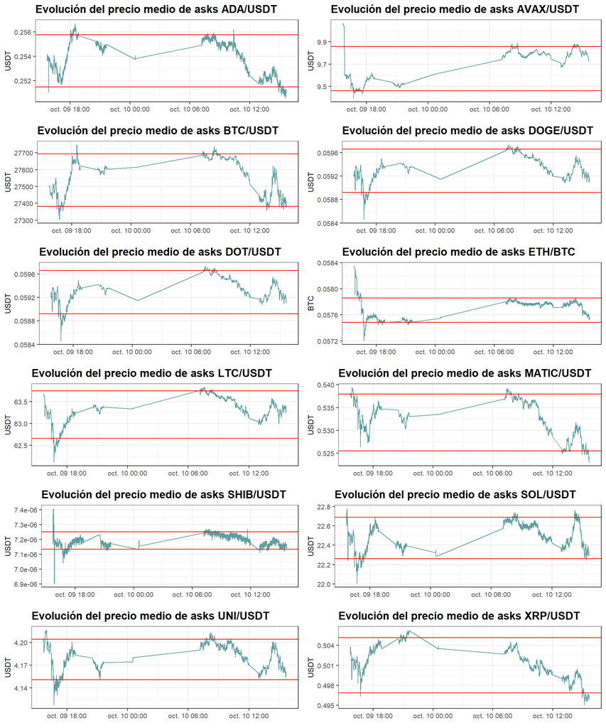

```r
p1 <- grafica_evolucion_media_asks(datos_ADA_USDT, "10 sec", "Evolución del precio medio de asks ADA/USDT", "USDT", c(.05, .95))
p2 <- grafica_evolucion_media_asks(datos_AVAX_USDT, "10 sec", "Evolución del precio medio de asks AVAX/USDT", "USDT", c(.05, .95))
p3 <- grafica_evolucion_media_asks(datos_BTC_USDT, "10 sec", "Evolución del precio medio de asks BTC/USDT", "USDT", c(.05, .95))
p4 <- grafica_evolucion_media_asks(datos_DOGE_USDT, "10 sec", "Evolución del precio medio de asks DOGE/USDT", "USDT", c(.05, .95))
p5 <- grafica_evolucion_media_asks(datos_DOT_USDT, "10 sec", "Evolución del precio medio de asks DOT/USDT", "USDT", c(.05, .95))
p6 <- grafica_evolucion_media_asks(datos_ETH_BTC, "10 sec", "Evolución del precio medio de asks ETH/BTC", "BTC", c(.05, .95))
p7 <- grafica_evolucion_media_asks(datos_LTC_USDT, "10 sec", "Evolución del precio medio de asks LTC/USDT", "USDT", c(.05, .95))
p8 <- grafica_evolucion_media_asks(datos_MATIC_USDT, "10 sec", "Evolución del precio medio de asks MATIC/USDT", "USDT", c(.05, .95))
p9 <- grafica_evolucion_media_asks(datos_SHIB_USDT, "10 sec", "Evolución del precio medio de asks SHIB/USDT", "USDT", c(.05, .95))
p10 <- grafica_evolucion_media_asks(datos_SOL_USDT, "10 sec", "Evolución del precio medio de asks SOL/USDT", "USDT", c(.05, .95))
p11 <- grafica_evolucion_media_asks(datos_UNI_USDT, "10 sec", "Evolución del precio medio de asks UNI/USDT", "USDT", c(.05, .95))
p12 <- grafica_evolucion_media_asks(datos_XRP_USDT, "10 sec", "Evolución del precio medio de asks XRP/USDT", "USDT", c(.05, .95))

ggarrange(ggarrange(p1, p2),
          ggarrange(p3, p4),
          ggarrange(p5, p6),
          ggarrange(p7, p8),
          ggarrange(p9, p10),
          ggarrange(p11, p12),
          nrow = 6
          )
```

### 4.5 Variación del precio medio de demanda con señales de alerta

Podemos mirar también la variación del precio medio de la demand, aunque en este caso, debemos quitar las variaciones correspondientes a los espaciones de tiempo de los que no disponemos de datos porque nos generan mucho ruido.

```r
grafica_evolucion_var_media_bids <- function (datos, time_lag, titulo_grafico, limits) {
  datos_agrupados <- datos %>%
    mutate(Hora_agrupada = cut(Hora, breaks = time_lag)) %>%
    filter(tiempoLlegada < 1) %>%
    group_by(Hora_agrupada) %>%
    summarize(varMediaBidsAgrupada = mean(varPrecioMedioBids)) %>%
    mutate(Hora_agrupada = as.POSIXct(Hora_agrupada))

  ggplot(datos_agrupados, aes(x = Hora_agrupada, y = varMediaBidsAgrupada, group = 1)) +
    geom_line(size = 0.5, color = "#0047AB") +
    ggtitle(titulo_grafico) +
    theme_bw() +
    theme(axis.text = element_text(size = 8), axis.title =  element_text(size = 9), plot.title = element_text(face = 'bold')) +
    labs(x = element_blank(), y = "%") +
    geom_hline(yintercept = quantile(datos_agrupados$varMediaBidsAgrupada, limits, na.rm = T), color = "red")
}
```

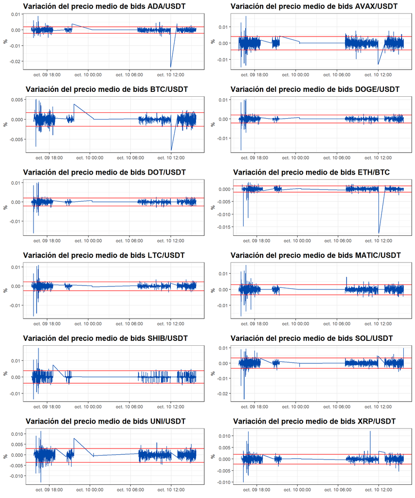

```r
p1 <- grafica_evolucion_var_media_bids(datos_ADA_USDT, "10 sec", "Variación del precio medio de bids ADA/USDT", c(.01, .99))
p2 <- grafica_evolucion_var_media_bids(datos_AVAX_USDT, "10 sec", "Variación del precio medio de bids AVAX/USDT", c(.01, .99))
p3 <- grafica_evolucion_var_media_bids(datos_BTC_USDT, "10 sec", "Variación del precio medio de bids BTC/USDT", c(.01, .99))
p4 <- grafica_evolucion_var_media_bids(datos_DOGE_USDT, "10 sec", "Variación del precio medio de bids DOGE/USDT", c(.01, .99))
p5 <- grafica_evolucion_var_media_bids(datos_DOT_USDT, "10 sec", "Variación del precio medio de bids DOT/USDT", c(.01, .99))
p6 <- grafica_evolucion_var_media_bids(datos_ETH_BTC, "10 sec", "Variación del precio medio de bids ETH/BTC", c(.01, .99))
p7 <- grafica_evolucion_var_media_bids(datos_LTC_USDT, "10 sec", "Variación del precio medio de bids LTC/USDT", c(.01, .99))
p8 <- grafica_evolucion_var_media_bids(datos_MATIC_USDT, "10 sec", "Variación del precio medio de bids MATIC/USDT", c(.01, .99))
p9 <- grafica_evolucion_var_media_bids(datos_SHIB_USDT, "10 sec", "Variación del precio medio de bids SHIB/USDT", c(.01, .99))
p10 <- grafica_evolucion_var_media_bids(datos_SOL_USDT, "10 sec", "Variación del precio medio de bids SOL/USDT", c(.01, .99))
p11 <- grafica_evolucion_var_media_bids(datos_UNI_USDT, "10 sec", "Variación del precio medio de bids UNI/USDT", c(.01, .99))
p12 <- grafica_evolucion_var_media_bids(datos_XRP_USDT, "10 sec", "Variación del precio medio de bids XRP/USDT", c(.01, .99))

ggarrange(ggarrange(p1, p2),
          ggarrange(p3, p4),
          ggarrange(p5, p6),
          ggarrange(p7, p8),
          ggarrange(p9, p10),
          ggarrange(p11, p12),
          nrow = 6
          )
```

### 4.6 Sentimiento compra-venta

El sentimiento compra-venta lo calculamos como la ratio entre bids y asks.

- Un valor muy bajo implica que mucha gente quiere vender frente a poca gente que quiere comprar.
- Un valor muy alto implica que mucha gente quiere comprar frente a poca gente que quiere vender.

```r
grafica_evolucion_compra_venta <- function (datos, time_lag, titulo_grafico, y_label) {
  datos_agrupados <- datos %>%
    mutate(Hora_agrupada = cut(Hora, breaks = time_lag)) %>%
    group_by(Hora_agrupada) %>%
    summarize(compraVentaAgrupada = mean(sentimientoCompraVenta)) %>%
    mutate(Hora_agrupada = as.POSIXct(Hora_agrupada))

  ggplot(datos_agrupados, aes(x = Hora_agrupada, y = compraVentaAgrupada, group = 1)) +
    geom_line(size = 0.5, color = "#0047AB") +
    ggtitle(titulo_grafico) +
    theme_bw() +
    theme(axis.text = element_text(size = 8), axis.title =  element_text(size = 9), plot.title = element_text(face = 'bold')) +
    labs(x = element_blank(), y = y_label)
}
```

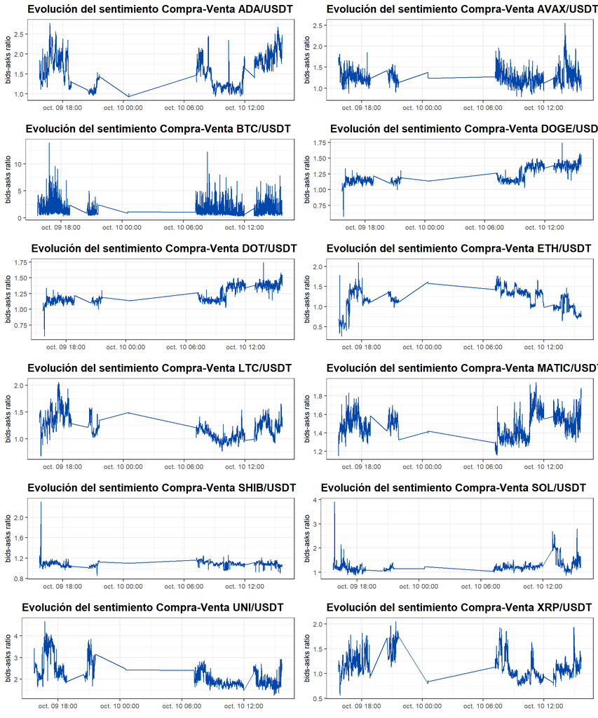

```r
p1 <- grafica_evolucion_compra_venta(datos_ADA_USDT, "10 sec", "Evolución del sentimiento Compra-Venta ADA/USDT", "bids-asks ratio")
p2 <- grafica_evolucion_compra_venta(datos_AVAX_USDT, "10 sec", "Evolución del sentimiento Compra-Venta AVAX/USDT", "bids-asks ratio")
p3 <- grafica_evolucion_compra_venta(datos_BTC_USDT, "10 sec", "Evolución del sentimiento Compra-Venta BTC/USDT", "bids-asks ratio")
p4 <- grafica_evolucion_compra_venta(datos_DOGE_USDT, "10 sec", "Evolución del sentimiento Compra-Venta DOGE/USDT", "bids-asks ratio")
p5 <- grafica_evolucion_compra_venta(datos_DOT_USDT, "10 sec", "Evolución del sentimiento Compra-Venta DOT/USDT", "bids-asks ratio")
p6 <- grafica_evolucion_compra_venta(datos_ETH_BTC, "10 sec", "Evolución del sentimiento Compra-Venta ETH/USDT", "bids-asks ratio")
p7 <- grafica_evolucion_compra_venta(datos_LTC_USDT, "10 sec", "Evolución del sentimiento Compra-Venta LTC/USDT", "bids-asks ratio")
p8 <- grafica_evolucion_compra_venta(datos_MATIC_USDT, "10 sec", "Evolución del sentimiento Compra-Venta MATIC/USDT", "bids-asks ratio")
p9 <- grafica_evolucion_compra_venta(datos_SHIB_USDT, "10 sec", "Evolución del sentimiento Compra-Venta SHIB/USDT", "bids-asks ratio")
p10 <- grafica_evolucion_compra_venta(datos_SOL_USDT, "10 sec", "Evolución del sentimiento Compra-Venta SOL/USDT", "bids-asks ratio")
p11 <- grafica_evolucion_compra_venta(datos_UNI_USDT, "10 sec", "Evolución del sentimiento Compra-Venta UNI/USDT", "bids-asks ratio")
p12 <- grafica_evolucion_compra_venta(datos_XRP_USDT, "10 sec", "Evolución del sentimiento Compra-Venta XRP/USDT", "bids-asks ratio")

ggarrange(ggarrange(p1, p2),
          ggarrange(p3, p4),
          ggarrange(p5, p6),
          ggarrange(p7, p8),
          ggarrange(p9, p10),
          ggarrange(p11, p12),
          nrow = 6
          )
```

## 5. Apéndice de funciones auxilliares y operaciones realizadas para transformar los csv iniciales en los ficheros que finalmente cargamos.

A continuación se muestran las funciones auxiliares y operaciones realizadas para transformar los csv iniciales en los ficheros que finalmente cargamos dentro de este fichero.

Por problemas en rendimiento y memoria hemos tenido que realizar un preprocesamiento de los datos hasta tenerlos en el formato con el que vamos a trabajar y que mostramos al inicio de este documento.

Carga de la información cuantitativa de cada monedas en un único dataset, leyendo también la última columna que tiene información en formato json:

```r
#read_symbol <- function (fname, symbol) {
#  df <- fread(fname)
#  colnames(df) <- c("Hora", "Exchange","Divisa", "Datos")
#  df <- df[df$Divisa == symbol]
#  df$Datos <- gsub("\\n", "", gsub("'", "\"", gsub("None", "\"0\"", df$Datos)))

#  df_json <- jsonlite::stream_in(textConnection(df$Datos), pagesize = 10000)

#  df_json$Exchange <- df$Exchange
#  df_json$Hora <- df$Hora

#  df = select(df_json, -4:-6)

#  return(df)
#}


#for (symbol in symbols) {
#  rm(info_symbol)
#  gc()

#  info_symbol <- data.frame()

#  info_symbol <- list.files(path = 'Data/información_cuantitava_monedas_reto2', pattern = "*.csv", full.names = TRUE, recursive = TRUE) %>%
#    map_df(~rbind(read_symbol(.x, symbol), info_symbol))

  # Guardamos
#  save(info_symbol, file=paste("crypto_orderbooks_", gsub("/", "_", symbol), ".Rda", sep = ""))
#}
```

Ponemos nombres a las columnas y hacemos un dataset por cada cryptodivisa (A modo de ejemplo ponemos el de BTC)

```r
# colnames(info_cuantitativa) <- c("Hora", "Exchange","Divisa", "Datos")
# infoBTCUSD<-info_cuantitativa[info_cuantitativa$Divisa == 'BTC/USDT']
```

Calculamos para cada dataframe los valores que luego vamos a utilizar para el análisis y que luego nos permiten eliminar las columnas con las listas, que ocupan demasiada memoria.

```r
#
#  for (i in 1:nrow(info_symbol)){
#    info_symbol$mediaBids[i] <- mean(info_symbol$bids[[i]][,1])
#    info_symbol$profundidad[i] <- sum(info_symbol$bids[[i]][,2])
#    info_symbol$mediaAsks[i] <- mean(info_symbol$asks[[i]][,1])
#    info_symbol$profundidadAsks[i] <- sum(info_symbol$asks[[i]][,2])
#  }
#
#
# info_symbol <- info_symbol %>%
#    arrange(Exchange, Hora) %>%
#    mutate(varPrecioMedioBids = 100 * (mediaBids - lag(mediaBids)) / lag(mediaBids)) %>%
#    mutate(varProfundidadBids = 100 * (profundidad - lag(profundidad)) / lag(profundidad)) %>%
#    mutate(varPrecioMedioAsks = 100 * (mediaAsks - lag(mediaAsks)) / lag(mediaAsks)) %>%
#    mutate(varProfundidadAsks = 100 * (profundidadAsks - lag(profundidadAsks)) / lag(profundidadAsks))%>%
#    mutate(tiempoLlegada = (Hora - lag(Hora))) %>%
#    mutate(sentimientoCompraVenta = (profundidad / profundidadAsks))
#
# #Eliminamos las listas
# info_symbol<-select(info_symbol, -2:-3)
```

```r
# save(datos_ADA_USDT, file=paste("crypto_orderbooks_", "agregados_ADA_USDT.Rda", sep = ""))
# save(datos_AVAX_USDT, file=paste("crypto_orderbooks_", "agregados_AVAX_USDT.Rda", sep = ""))
# save(datos_BTC_USDT, file=paste("crypto_orderbooks_", "agregados_BTC_USDT.Rda", sep = ""))
# save(datos_DOT_USDT, file=paste("crypto_orderbooks_", "agregados_DOT_USDT.Rda", sep = ""))
# save(datos_LTC_USDT, file=paste("crypto_orderbooks_", "agregados_LTC_USDT.Rda", sep = ""))
# save(datos_MATIC_USDT, file=paste("crypto_orderbooks_", "agregados_MATIC_USDT.Rda", sep = ""))
# save(datos_SHIB_USDT, file=paste("crypto_orderbooks_", "agregados_SHIB_USDT.Rda", sep = ""))
# save(datos_SOL_USDT, file=paste("crypto_orderbooks_", "agregados_SOL_USDT.Rda", sep = ""))
# save(datos_UNI_USDT, file=paste("crypto_orderbooks_", "agregados_UNI_USDT.Rda", sep = ""))
# save(datos_XRP_USDT, file=paste("crypto_orderbooks_", "agregados_XRP_USDT.Rda", sep = ""))
# save(datos_ETH_BTC, file=paste("crypto_orderbooks_", "agregados_ETH_BTC.Rda", sep = ""))
# save(datos_DOGE_USDT, file=paste("crypto_orderbooks_", "agregados_DOGE_USDT.Rda", sep = ""))
```